# Modeling Assignment Case Competition

RJ Hazen, Marcus Needham, Hunter Nilsen

2024-11-03

# Capstone Final Project - Predictive Maintenece: Swire Coca-Cola

## Introduction

For this modeling assignment, we aim to build predictive models to identify key factors driving machine breakdowns within Swire Coca-Cola’s production facilities. Leveraging data from the Internal Warehouse Controller (IWC) system, which monitors machine downtimes, repairs, and maintenance activities across various sites, our goal is to develop models that not only predict the likelihood of future breakdowns but also provide actionable insights to reduce downtime. By analyzing predictive indicators such as average downtime, machine age, and maintenance schedules, this project seeks to enhance operational efficiency and support data-driven decision-making for maintenance management.

### Problem Statement:

Swire Coca-Cola faces significant losses, around $60 million annually, due to unplanned machine breakdowns. The company wants to reduce these losses by identifying patterns in downtime and developing a predictive maintenance model that can foresee breakdowns before they happen. This would allow the company to better plan for repairs and minimize downtime.

### Objectives:

The key objectives of this analysis are to:

## Loading the Necessary Packages

```r
# Load necessary libraries
library(dplyr)
library(caret)
library(lubridate)
library(randomForest)
library(rpart)
library(dplyr)
library(zoo)
library(xgboost)
library(Matrix)
```

## Loading in the Data

```r
# Load the dataset
data <- read.csv("cleaned_IWC_Work_Orders.csv")
```

# Additional EDA

## Breaking Up Data by Planned and Unplanned

```r
unplanned_data <- data %>%
  filter(MAINTENANCE_ACTIVITY_TYPE == "Unplanned")

# Calculate the count of NAs and blanks in each column for these filtered rows
na_blank_count_by_column_unplanned <- sapply(unplanned_data, function(x) sum(is.na(x) | x == ""))

# Convert to data frame for better readability
na_blank_count_df_unplanned <- data.frame(Column = names(na_blank_count_by_column_unplanned), NA_Blank_Count = na_blank_count_by_column_unplanned)
print(na_blank_count_df_unplanned)
```

```
##                                                          Column NA_Blank_Count
## ORDER_ID                                               ORDER_ID              0
## PLANT_ID                                               PLANT_ID              0
## PRODUCTION_LOCATION                         PRODUCTION_LOCATION              0
## EXECUTION_START_DATE                       EXECUTION_START_DATE              0
## EXECUTION_FINISH_DATE                     EXECUTION_FINISH_DATE              0
## ACTUAL_START_TIME                             ACTUAL_START_TIME              0
## ACTUAL_FINISH_TIME                           ACTUAL_FINISH_TIME              0
## ACTUAL_WORK_IN_MINUTES                   ACTUAL_WORK_IN_MINUTES              0
## MAINTENANCE_PLAN                               MAINTENANCE_PLAN        1274670
## MAINTENANCE_ITEM                               MAINTENANCE_ITEM        1274670
## MAINTENANCE_ACTIVITY_TYPE             MAINTENANCE_ACTIVITY_TYPE              0
## ORDER_DESCRIPTION                             ORDER_DESCRIPTION        1135494
## MAINTENANCE_TYPE_DESCRIPTION       MAINTENANCE_TYPE_DESCRIPTION        1135469
## FUNCTIONAL_LOC                                   FUNCTIONAL_LOC        1135475
## FUNCTIONAL_AREA_NODE_1_MODIFIED FUNCTIONAL_AREA_NODE_1_MODIFIED        1136034
## FUNCTIONAL_AREA_NODE_2_MODIFIED FUNCTIONAL_AREA_NODE_2_MODIFIED        1141772
## FUNCTIONAL_AREA_NODE_3_MODIFIED FUNCTIONAL_AREA_NODE_3_MODIFIED        1150377
## FUNCTIONAL_AREA_NODE_4_MODIFIED FUNCTIONAL_AREA_NODE_4_MODIFIED        1155162
## FUNCTIONAL_AREA_NODE_5_MODIFIED FUNCTIONAL_AREA_NODE_5_MODIFIED        1275192
## EQUIPMENT_ID                                       EQUIPMENT_ID        1135469
## EQUIPMENT_DESC                                   EQUIPMENT_DESC        1252405
## EQUIP_CAT_DESC                                   EQUIP_CAT_DESC        1252405
## EQUIP_START_UP_DATE                         EQUIP_START_UP_DATE        1252405
## EQUIP_VALID_FROM                               EQUIP_VALID_FROM        1252405
## EQUIP_VALID_TO                                   EQUIP_VALID_TO        1252405
```

The missing data for unplanned maintenance events, especially in fields like MAINTENANCE_PLAN, MAINTENANCE_ITEM, and equipment details (EQUIP_START_UP_DATE, EQUIP_VALID_FROM, and EQUIP_VALID_TO), suggests that detailed information is often not captured during urgent, unplanned repairs. This lack of detail can limit predictive analyses, as it makes it harder to identify patterns tied to specific equipment, maintenance items, or plant areas.

As a result, predictive maintenance models may have reduced accuracy when trying to forecast unplanned downtimes based on equipment characteristics or maintenance specifics. Addressing these gaps might involve using imputation techniques, focusing on available data for broader trends, or seeking additional data to fill in missing details.

```r
planned_data <- data %>%
  filter(MAINTENANCE_ACTIVITY_TYPE == "Planned")

# Calculate the count of NAs and blanks in each column for these filtered rows
na_blank_count_by_column_planned <- sapply(planned_data, function(x) sum(is.na(x) | x == ""))

# Convert to data frame for better readability
na_blank_count_df_planned <- data.frame(Column = names(na_blank_count_by_column_planned), NA_Blank_Count = na_blank_count_by_column_planned)
print(na_blank_count_df_planned)
```

```
##                                                          Column NA_Blank_Count
## ORDER_ID                                               ORDER_ID              0
## PLANT_ID                                               PLANT_ID              0
## PRODUCTION_LOCATION                         PRODUCTION_LOCATION              0
## EXECUTION_START_DATE                       EXECUTION_START_DATE              0
## EXECUTION_FINISH_DATE                     EXECUTION_FINISH_DATE              0
## ACTUAL_START_TIME                             ACTUAL_START_TIME              0
## ACTUAL_FINISH_TIME                           ACTUAL_FINISH_TIME              0
## ACTUAL_WORK_IN_MINUTES                   ACTUAL_WORK_IN_MINUTES              0
## MAINTENANCE_PLAN                               MAINTENANCE_PLAN              0
## MAINTENANCE_ITEM                               MAINTENANCE_ITEM              0
## MAINTENANCE_ACTIVITY_TYPE             MAINTENANCE_ACTIVITY_TYPE              0
## ORDER_DESCRIPTION                             ORDER_DESCRIPTION              3
## MAINTENANCE_TYPE_DESCRIPTION       MAINTENANCE_TYPE_DESCRIPTION              0
## FUNCTIONAL_LOC                                   FUNCTIONAL_LOC              7
## FUNCTIONAL_AREA_NODE_1_MODIFIED FUNCTIONAL_AREA_NODE_1_MODIFIED           1113
## FUNCTIONAL_AREA_NODE_2_MODIFIED FUNCTIONAL_AREA_NODE_2_MODIFIED           3085
## FUNCTIONAL_AREA_NODE_3_MODIFIED FUNCTIONAL_AREA_NODE_3_MODIFIED          18196
## FUNCTIONAL_AREA_NODE_4_MODIFIED FUNCTIONAL_AREA_NODE_4_MODIFIED          34529
## FUNCTIONAL_AREA_NODE_5_MODIFIED FUNCTIONAL_AREA_NODE_5_MODIFIED         149892
## EQUIPMENT_ID                                       EQUIPMENT_ID              0
## EQUIPMENT_DESC                                   EQUIPMENT_DESC          95412
## EQUIP_CAT_DESC                                   EQUIP_CAT_DESC          95412
## EQUIP_START_UP_DATE                         EQUIP_START_UP_DATE          95412
## EQUIP_VALID_FROM                               EQUIP_VALID_FROM          95412
## EQUIP_VALID_TO                                   EQUIP_VALID_TO          95412
```

For planned maintenance records, most key fields—like identifiers, timestamps, and high-level maintenance descriptions—have no missing data. This makes it easy to analyze the frequency and timing of planned maintenance across different plants and functional areas. However, as we move to more detailed columns, such as specific functional area nodes and equipment lifespan information, missing values start to appear, especially in FUNCTIONAL_AREA_NODE_5_MODIFIED and equipment-related fields like EQUIP_START_UP_DATE.

These gaps in detailed data suggest that certain information, particularly at the component level, may not be consistently captured or is less relevant for planned maintenance activities. While this won’t impact high-level analysis, it could limit deeper insights into specific equipment or component-level maintenance patterns if required for more granular predictive models or lifecycle analyses.

## Downtime Visual

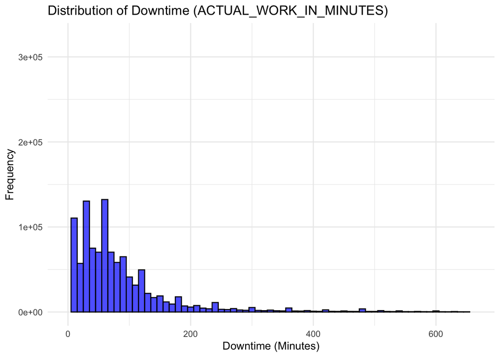

```r
#Plot the distribution of `ACTUAL_WORK_IN_MINUTES`
ggplot(data, aes(x = ACTUAL_WORK_IN_MINUTES)) +
  geom_histogram(binwidth = 10, fill = "blue", color = "black", alpha = 0.7) +
  scale_x_continuous(limits = c(0, quantile(data$ACTUAL_WORK_IN_MINUTES, 0.99, na.rm = TRUE))) +
  labs(
    title = "Distribution of Downtime (ACTUAL_WORK_IN_MINUTES)",
    x = "Downtime (Minutes)",
    y = "Frequency"
  ) +
  theme_minimal()
```

```r
#Calculate quantiles of `ACTUAL_WORK_IN_MINUTES`
quantiles <- quantile(data$ACTUAL_WORK_IN_MINUTES, probs = seq(0, 1, 0.1), na.rm = TRUE)
print(quantiles)
```

```
##       0%      10%      20%      30%      40%      50%      60%      70%
##      0.0      0.0      1.0     15.0     30.0     48.0     60.0     80.0
##      80%      90%     100%
##    108.0    165.0 330184.8
```

```r
# Step 3: Determine potential thresholds based on quantiles
# Let's say we consider downtimes longer than the 75th, 80th, or 90th percentiles as significant


# We know the 75th, 80th, and 90th percentiles correspond to indices 8, 9, and 10 respectively
threshold_options <- c(quantiles[8], quantiles[9], quantiles[10])


# Create a summary of downtime events for each threshold
threshold_summary <- data.frame()

for (threshold in threshold_options) {
  high_risk_count <- sum(data$ACTUAL_WORK_IN_MINUTES > threshold, na.rm = TRUE)
  threshold_summary <- rbind(
    threshold_summary,
    data.frame(
      Threshold = threshold,
      HighRiskCount = high_risk_count,
      HighRiskPercent = high_risk_count / nrow(data) * 100
    )
  )
}

# Display the summary table
print(threshold_summary)
```

```
##   Threshold HighRiskCount HighRiskPercent
## 1        80        426707       29.896852
## 2       108        282046       19.761306
## 3       165        142050        9.952609
```

This output provides insights into the duration and frequency of downtime events. The high-risk summary table shows that, depending on the threshold, between 10% and 30% of downtimes are significant enough to potentially impact operations. This information can guide maintenance teams in prioritizing resources to reduce these longer downtime events, as they represent the most impactful delays.

# XGBoost Model

We will utilize the subset of data where the Maintenance Activity Type is planned to more accurately predict maintenance downtime to create a proactive, data-driven maintenance strategy.

## Step 1: Prepare the Data

```r
# Filter for planned maintenance only
planned_data <- data %>% filter(MAINTENANCE_ACTIVITY_TYPE == "Planned")
```

## Step 2: Data Cleaning

```r
# Convert date columns to Date format
planned_data$EQUIP_START_UP_DATE <- as.Date(planned_data$EQUIP_START_UP_DATE, format = "%Y-%m-%d")
planned_data$EQUIP_VALID_FROM <- as.Date(planned_data$EQUIP_VALID_FROM, format = "%Y-%m-%d")
planned_data$EXECUTION_START_DATE <- as.Date(planned_data$EXECUTION_START_DATE, format = "%Y-%m-%d")

# Calculate equipment age at the time of maintenance
planned_data$equipment_age <- as.numeric(difftime(planned_data$EXECUTION_START_DATE, planned_data$EQUIP_START_UP_DATE, units = "days")) / 365.25

# Replace missing values (NA and blanks) in categorical variables with "Unknown"
planned_data$MAINTENANCE_PLAN[is.na(planned_data$MAINTENANCE_PLAN) | planned_data$MAINTENANCE_PLAN == ""] <- "Unknown"
planned_data$MAINTENANCE_ITEM[is.na(planned_data$MAINTENANCE_ITEM) | planned_data$MAINTENANCE_ITEM == ""] <- "Unknown"
planned_data$MAINTENANCE_TYPE_DESCRIPTION[is.na(planned_data$MAINTENANCE_TYPE_DESCRIPTION) | planned_data$MAINTENANCE_TYPE_DESCRIPTION == ""] <- "Unknown"

# Replace missing values in numerical variables with the median
planned_data$equipment_age[is.na(planned_data$equipment_age) | planned_data$equipment_age == ""] <- median(planned_data$equipment_age, na.rm = TRUE)

# Drop irrelevant or high-missing columns (e.g., identifiers, and columns with over 50% missing data)
planned_data <- planned_data %>%
  select(-c(ORDER_ID, EQUIP_VALID_TO, EQUIP_VALID_FROM, EQUIP_START_UP_DATE))

# Encoding categorical variables to numeric for XGBoost
planned_data$MAINTENANCE_PLAN <- as.numeric(as.factor(planned_data$MAINTENANCE_PLAN))
planned_data$MAINTENANCE_ITEM <- as.numeric(as.factor(planned_data$MAINTENANCE_ITEM))
planned_data$MAINTENANCE_TYPE_DESCRIPTION <- as.numeric(as.factor(planned_data$MAINTENANCE_TYPE_DESCRIPTION))
```

## Step 3: Split Data for Modeling

```r
# planned_data <- planned_data %>%
#   mutate_if(is.character, as.factor) %>%    # Convert characters to factors
#   mutate_if(is.factor, as.numeric)
# # Split the data into training and testing sets
# set.seed(123)
# trainIndex <- createDataPartition(planned_data$ACTUAL_WORK_IN_MINUTES, p = 0.8, list = FALSE)
# train_data_XG <- planned_data[trainIndex, ]
# test_data_XG <- planned_data[-trainIndex, ]
#
# # Separate features and target variable
# train_matrix <- xgb.DMatrix(data = as.matrix(train_data_XG %>% select(-ACTUAL_WORK_IN_MINUTES)),
#                             label = train_data_XG$ACTUAL_WORK_IN_MINUTES)
# test_matrix <- xgb.DMatrix(data = as.matrix(test_data_XG %>% select(-ACTUAL_WORK_IN_MINUTES)),
#                            label = test_data_XG$ACTUAL_WORK_IN_MINUTES)
```

## Step 4: Train the Model

```r
# # Model Training
#
# # Set XGBoost parameters
# params <- list(
#   objective = "reg:squarederror",  # for regression
#   eval_metric = "rmse",            # root mean squared error
#   max_depth = 6,
#   eta = 0.1,
#   subsample = 0.8,
#   colsample_bytree = 0.8
# )
#
# # Train the XGBoost model
# xgb_model <- xgb.train(
#   params = params,
#   data = train_matrix,
#   nrounds = 100,
#   watchlist = list(train = train_matrix, test = test_matrix),
#   early_stopping_rounds = 10,    # stop early if no improvement
#   print_every_n = 10
# )
#
# # Model Evaluation
# predictions <- predict(xgb_model, test_matrix)
# rmse <- sqrt(mean((predictions - test_data$ACTUAL_WORK_IN_MINUTES)^2))
# print(paste("RMSE on test set:", rmse))
#
# # Feature Importance
# importance <- xgb.importance(model = xgb_model)
# xgb.plot.importance(importance)
```

The purpose of developing an XGBoost model to predict downtime duration for planned maintenance is to help the maintenance team and production managers at Swire Coca-Cola optimize their maintenance scheduling and resource allocation. By accurately forecasting how long each planned maintenance event will take, the business can make more informed decisions about resource planning, inventory management, and production scheduling, ultimately improving operational efficiency and reducing costs. This model is a work in progress and will fine tune it so we are able to provide an actionable plan come time for the presentation.

# Random Forest Model

## Step 1: Prepare the Data

```r
# Create data for Random Forest
rf_data <- data

# View the Data
str(rf_data)
```

```
## 'data.frame':    1427264 obs. of  25 variables:
##  $ ORDER_ID                       : num  7.06e+08 7.04e+08 7.04e+08 7.04e+08 7.05e+08 ...
##  $ PLANT_ID                       : chr  "G812" "G812" "G812" "G812" ...
##  $ PRODUCTION_LOCATION            : chr  "ROMA" "ROMA" "ROMA" "ROMA" ...
##  $ EXECUTION_START_DATE           : chr  "2024-05-04" "2022-09-13" "2022-12-21" "2022-07-04" ...
##  $ EXECUTION_FINISH_DATE          : chr  "2024-05-12" "2022-09-13" "2022-12-21" "2022-07-04" ...
##  $ ACTUAL_START_TIME              : chr  "06:00:00.000" "06:00:00.000" "07:00:00.000" "06:00:00.000" ...
##  $ ACTUAL_FINISH_TIME             : chr  "23:04:08.000" "17:17:24.000" "07:00:00.000" "06:00:00.000" ...
##  $ ACTUAL_WORK_IN_MINUTES         : num  390 420 30 60 120 18 480 30 30 30 ...
##  $ MAINTENANCE_PLAN               : chr  "" "" "" "" ...
##  $ MAINTENANCE_ITEM               : int  NA NA NA NA NA 40534 NA NA NA NA ...
##  $ MAINTENANCE_ACTIVITY_TYPE      : chr  "Unplanned" "Unplanned" "Unplanned" "Unplanned" ...
##  $ ORDER_DESCRIPTION              : chr  "L2 GEARBOX LEAK (SEE ATTACHED)" "LINE 3 CONVEYOR AT CAN CODER" "BROKEN CONVEYOR RAIL" "LINE 3 CONVEYOR" ...
##  $ MAINTENANCE_TYPE_DESCRIPTION   : chr  "Corrective Maintenance Order" "Corrective Maintenance Order" "Corrective Maintenance Order" "Corrective Maintenance Order" ...
##  $ FUNCTIONAL_LOC                 : chr  "G812-PRD-L15-L03-L030-020" "G812-PRD-L15-L03-L030-020" "G812-PRD-L15-L03-L030-020" "G812-PRD-L15-L03-L030-020" ...
##  $ FUNCTIONAL_AREA_NODE_1_MODIFIED: chr  "PRODUCTION" "PRODUCTION" "PRODUCTION" "PRODUCTION" ...
##  $ FUNCTIONAL_AREA_NODE_2_MODIFIED: chr  "G812 PRD FILLER_ROTARY_CAN" "G812 PRD FILLER_ROTARY_CAN" "G812 PRD FILLER_ROTARY_CAN" "G812 PRD FILLER_ROTARY_CAN" ...
##  $ FUNCTIONAL_AREA_NODE_3_MODIFIED: chr  "G812 PRD FILLER_ROTARY_CAN LINE 3" "G812 PRD FILLER_ROTARY_CAN LINE 3" "G812 PRD FILLER_ROTARY_CAN LINE 3" "G812 PRD FILLER_ROTARY_CAN LINE 3" ...
##  $ FUNCTIONAL_AREA_NODE_4_MODIFIED: chr  "CONVEYOR" "CONVEYOR" "CONVEYOR" "CONVEYOR" ...
##  $ FUNCTIONAL_AREA_NODE_5_MODIFIED: chr  "FULL CAN CONVEYOR" "FULL CAN CONVEYOR" "FULL CAN CONVEYOR" "FULL CAN CONVEYOR" ...
##  $ EQUIPMENT_ID                   : int  300126812 300126812 300126812 300126812 300001088 300001088 300001088 300001033 300001033 300001033 ...
##  $ EQUIPMENT_DESC                 : chr  "FULL CAN CONVEYOR (FC41B)" "FULL CAN CONVEYOR (FC41B)" "FULL CAN CONVEYOR (FC41B)" "FULL CAN CONVEYOR (FC41B)" ...
##  $ EQUIP_CAT_DESC                 : chr  "Machines" "Machines" "Machines" "Machines" ...
##  $ EQUIP_START_UP_DATE            : chr  "2020-04-22" "2020-04-22" "2020-04-22" "2020-04-22" ...
##  $ EQUIP_VALID_FROM               : chr  "2020-02-10" "2020-02-10" "2020-02-10" "2020-02-10" ...
##  $ EQUIP_VALID_TO                 : chr  "9999-12-31" "9999-12-31" "9999-12-31" "9999-12-31" ...
```

```r
head(rf_data)
```

```
##    ORDER_ID PLANT_ID PRODUCTION_LOCATION EXECUTION_START_DATE
## 1 705642457     G812                ROMA           2024-05-04
## 2 704191697     G812                ROMA           2022-09-13
## 3 704466547     G812                ROMA           2022-12-21
## 4 703834477     G812                ROMA           2022-07-04
## 5 704661125     G291               MONZA           2023-03-15
## 6 704948720     G291               MONZA           2023-09-08
##   EXECUTION_FINISH_DATE ACTUAL_START_TIME ACTUAL_FINISH_TIME
## 1            2024-05-12      06:00:00.000       23:04:08.000
## 2            2022-09-13      06:00:00.000       17:17:24.000
## 3            2022-12-21      07:00:00.000       07:00:00.000
## 4            2022-07-04      06:00:00.000       06:00:00.000
## 5            2023-03-15      07:00:00.000       07:00:00.000
## 6            2023-09-08      07:00:00.000       07:00:00.000
##   ACTUAL_WORK_IN_MINUTES MAINTENANCE_PLAN MAINTENANCE_ITEM
```

[output cut: 48 more lines]

```r
# Convert empty strings or "NA" strings to true NA values if necessary
rf_data$EQUIPMENT_ID[rf_data$EQUIPMENT_ID == ""] <- NA
rf_data$EQUIPMENT_ID[rf_data$EQUIPMENT_ID == "NA"] <- NA

# Remove rows with missing EQUIPMENT_ID if the group decided to do so
rf_data <- rf_data %>% filter(!is.na(EQUIPMENT_ID))
head(rf_data)
```

```
##    ORDER_ID PLANT_ID PRODUCTION_LOCATION EXECUTION_START_DATE
## 1 705642457     G812                ROMA           2024-05-04
## 2 704191697     G812                ROMA           2022-09-13
## 3 704466547     G812                ROMA           2022-12-21
## 4 703834477     G812                ROMA           2022-07-04
## 5 704661125     G291               MONZA           2023-03-15
## 6 704948720     G291               MONZA           2023-09-08
##   EXECUTION_FINISH_DATE ACTUAL_START_TIME ACTUAL_FINISH_TIME
## 1            2024-05-12      06:00:00.000       23:04:08.000
## 2            2022-09-13      06:00:00.000       17:17:24.000
## 3            2022-12-21      07:00:00.000       07:00:00.000
## 4            2022-07-04      06:00:00.000       06:00:00.000
## 5            2023-03-15      07:00:00.000       07:00:00.000
## 6            2023-09-08      07:00:00.000       07:00:00.000
##   ACTUAL_WORK_IN_MINUTES MAINTENANCE_PLAN MAINTENANCE_ITEM
```

[output cut: 48 more lines]

```r
# Confirm the number of rows after filtering
print(paste("Number of rows remaining after filtering:", nrow(rf_data)))
```

```
## [1] "Number of rows remaining after filtering: 291795"
```

## Step 2: Define the Target Variable

```r
# Define threshold for downtime
threshold <- 60  # Adjust this as needed
rf_data$failure_risk <- ifelse(rf_data$ACTUAL_WORK_IN_MINUTES > threshold, 1, 0)

# Randomly sample 100,000 rows if necessary due to memory constraints
set.seed(123)
sampled_data <- rf_data[sample(nrow(rf_data), 100000), ]


# Convert categorical variables to factors
sampled_data$PLANT_ID <- as.factor(sampled_data$PLANT_ID)
sampled_data$MAINTENANCE_ACTIVITY_TYPE <- as.factor(sampled_data$MAINTENANCE_ACTIVITY_TYPE)

# Remove rows with any missing values
sampled_data <- sampled_data[complete.cases(sampled_data), ]

# Confirm that there are no missing values left
colSums(is.na(sampled_data))
```

```
##                        ORDER_ID                        PLANT_ID
##                               0                               0
##             PRODUCTION_LOCATION            EXECUTION_START_DATE
##                               0                               0
##           EXECUTION_FINISH_DATE               ACTUAL_START_TIME
##                               0                               0
##              ACTUAL_FINISH_TIME          ACTUAL_WORK_IN_MINUTES
##                               0                               0
##                MAINTENANCE_PLAN                MAINTENANCE_ITEM
##                               0                               0
##       MAINTENANCE_ACTIVITY_TYPE               ORDER_DESCRIPTION
##                               0                               0
##    MAINTENANCE_TYPE_DESCRIPTION                  FUNCTIONAL_LOC
##                               0                               0
## FUNCTIONAL_AREA_NODE_1_MODIFIED FUNCTIONAL_AREA_NODE_2_MODIFIED
##                               0                               0
## FUNCTIONAL_AREA_NODE_3_MODIFIED FUNCTIONAL_AREA_NODE_4_MODIFIED
##                               0                               0
## FUNCTIONAL_AREA_NODE_5_MODIFIED                    EQUIPMENT_ID
##                               0                               0
##                  EQUIPMENT_DESC                  EQUIP_CAT_DESC
##                               0                               0
##             EQUIP_START_UP_DATE                EQUIP_VALID_FROM
##                               0                               0
##                  EQUIP_VALID_TO                    failure_risk
##                               0                               0
```

## Step 4: Split the Data into Training and Test Sets

```r
set.seed(123)  # For reproducibility
train_index <- sample(1:nrow(sampled_data), 0.8 * nrow(sampled_data))
train_data <- sampled_data[train_index, ]
test_data <- sampled_data[-train_index, ]
```

## Step 5: Fit the Random Forest Model

```r
# Convert the target variable to a factor for classification
train_data$failure_risk <- as.factor(train_data$failure_risk)
test_data$failure_risk <- as.factor(test_data$failure_risk)

# Re-run the Random Forest model as a classification model
rf_model <- randomForest(
  failure_risk ~ . - ACTUAL_WORK_IN_MINUTES,  # Exclude the original ACTUAL_WORK_IN_MINUTES column
  data = train_data,
  ntree = 100,  # Adjust as needed
  mtry = 3,     # Adjust based on the number of features
  importance = TRUE
)

# Print the model summary
print(rf_model)
```

```
##
## Call:
##  randomForest(formula = failure_risk ~ . - ACTUAL_WORK_IN_MINUTES,      data = train_data, ntree = 100, mtry = 3, importance = TRUE)
##                Type of random forest: classification
##                      Number of trees: 100
## No. of variables tried at each split: 3
##
##         OOB estimate of  error rate: 11.47%
## Confusion matrix:
##       0    1 class.error
## 0 33911  744  0.02146876
## 1  4092 3397  0.54640139
```

## Step 6: Predict and Evaluate the Model

```r
# Predict on the test set
rf_predictions <- predict(rf_model, test_data)

# Confusion matrix
confusionMatrix(rf_predictions, test_data$failure_risk)
```

```
## Confusion Matrix and Statistics
##
##           Reference
## Prediction    0    1
##          0 8263 1517
##          1  317  439
##
##                Accuracy : 0.8259
##                  95% CI : (0.8186, 0.8331)
##     No Information Rate : 0.8144
##     P-Value [Acc > NIR] : 0.001082
##
##                   Kappa : 0.2457
##
##  Mcnemar's Test P-Value : < 2.2e-16
##
##             Sensitivity : 0.9631
##             Specificity : 0.2244
##          Pos Pred Value : 0.8449
##          Neg Pred Value : 0.5807
##              Prevalence : 0.8144
##          Detection Rate : 0.7843
##    Detection Prevalence : 0.9282
##       Balanced Accuracy : 0.5937
##
##        'Positive' Class : 0
##
```

```r
# Accuracy
accuracy <- mean(rf_predictions == test_data$failure_risk)
print(paste("Test Accuracy:", accuracy))
```

```
## [1] "Test Accuracy: 0.825930144267274"
```

## Step 7: What makes a machine breakdown?

```r
# Define breakdown based on a downtime threshold
threshold <- 60  # Define breakdown as downtimes over 60 minutes
rf_data$breakdown <- ifelse(rf_data$ACTUAL_WORK_IN_MINUTES > threshold, 1, 0)

# Convert to factor for classification
rf_data$breakdown <- as.factor(rf_data$breakdown)

# Remove rows with any missing values for simplicity
sample_data <- rf_data[complete.cases(rf_data), ]

set.seed(123)  # For reproducibility
train_index <- sample(1:nrow(sample_data), 0.8 * nrow(sample_data))
train_data <- sample_data[train_index, ]
test_data <- sample_data[-train_index, ]
```

## Step 8: Train RF Model

```r
# Train the Random Forest model
rf_model <- randomForest(
  breakdown ~ . - ACTUAL_WORK_IN_MINUTES,  # Exclude downtime as it's the basis for breakdown
  data = train_data,
  ntree = 100,
  mtry = 3,
  importance = TRUE
)

# Print the model summary
print(rf_model)
```

```
##
## Call:
##  randomForest(formula = breakdown ~ . - ACTUAL_WORK_IN_MINUTES,      data = train_data, ntree = 100, mtry = 3, importance = TRUE)
##                Type of random forest: classification
##                      Number of trees: 100
## No. of variables tried at each split: 3
##
##         OOB estimate of  error rate: 0%
## Confusion matrix:
##        0     1 class.error
## 0 100080     0           0
## 1      0 21995           0
```

## Step 9: Plot RF Model

```r
# View and plot feature importance
importance <- importance(rf_model)
print(importance)
```

```
##                                         0         1 MeanDecreaseAccuracy
## ORDER_ID                         6.459971  5.968541             7.225329
## PLANT_ID                         4.217943  2.408235             4.612254
## PRODUCTION_LOCATION              5.035635  3.198521             5.413035
## EXECUTION_START_DATE             6.267306  6.824855             7.631886
## EXECUTION_FINISH_DATE            5.169949  6.196948             5.689163
## ACTUAL_START_TIME                6.833476  5.635039             7.498967
## ACTUAL_FINISH_TIME               8.259050  6.185003             8.803335
## MAINTENANCE_PLAN                 8.275564  7.074412             9.321236
## MAINTENANCE_ITEM                 9.049953  6.221867             9.241135
## MAINTENANCE_ACTIVITY_TYPE        2.978990  3.979156             4.831553
## ORDER_DESCRIPTION                8.186317  8.856500             9.434624
## MAINTENANCE_TYPE_DESCRIPTION     1.970428  4.240853             4.561270
## FUNCTIONAL_LOC                   7.592909  5.787481             8.114978
## FUNCTIONAL_AREA_NODE_1_MODIFIED  4.436757  4.017897             5.458155
## FUNCTIONAL_AREA_NODE_2_MODIFIED  6.062841  4.691232             6.920490
## FUNCTIONAL_AREA_NODE_3_MODIFIED  4.786032  4.910641             7.129673
## FUNCTIONAL_AREA_NODE_4_MODIFIED  9.289839  7.473119            10.352078
## FUNCTIONAL_AREA_NODE_5_MODIFIED  0.153997 -1.350836            -0.796114
## EQUIPMENT_ID                     6.893958  5.164021             7.432380
## EQUIPMENT_DESC                   4.505036  4.887899             5.116921
## EQUIP_CAT_DESC                   2.236889  2.348303             3.055361
## EQUIP_START_UP_DATE              2.161676  3.770350             2.854851
## EQUIP_VALID_FROM                 4.009509  3.067729             4.400982
## EQUIP_VALID_TO                   2.971744  1.381899             3.650808
## failure_risk                    66.917215 68.164934            69.702532
##                                 MeanDecreaseGini
## ORDER_ID                               357.20530
## PLANT_ID                               292.81557
## PRODUCTION_LOCATION                    248.39680
## EXECUTION_START_DATE                   361.09570
## EXECUTION_FINISH_DATE                  409.74035
## ACTUAL_START_TIME                      267.79059
## ACTUAL_FINISH_TIME                     292.82494
## MAINTENANCE_PLAN                       721.23095
## MAINTENANCE_ITEM                       799.15472
## MAINTENANCE_ACTIVITY_TYPE              163.89878
## ORDER_DESCRIPTION                      450.34096
## MAINTENANCE_TYPE_DESCRIPTION           291.36117
## FUNCTIONAL_LOC                         636.55259
## FUNCTIONAL_AREA_NODE_1_MODIFIED        196.55754
## FUNCTIONAL_AREA_NODE_2_MODIFIED        245.55197
## FUNCTIONAL_AREA_NODE_3_MODIFIED        289.96458
## FUNCTIONAL_AREA_NODE_4_MODIFIED        355.65632
## FUNCTIONAL_AREA_NODE_5_MODIFIED          6.28641
## EQUIPMENT_ID                           402.99256
## EQUIPMENT_DESC                         122.20720
## EQUIP_CAT_DESC                          25.17607
## EQUIP_START_UP_DATE                     38.39958
## EQUIP_VALID_FROM                        49.79969
## EQUIP_VALID_TO                          18.48000
## failure_risk                         26408.99134
```

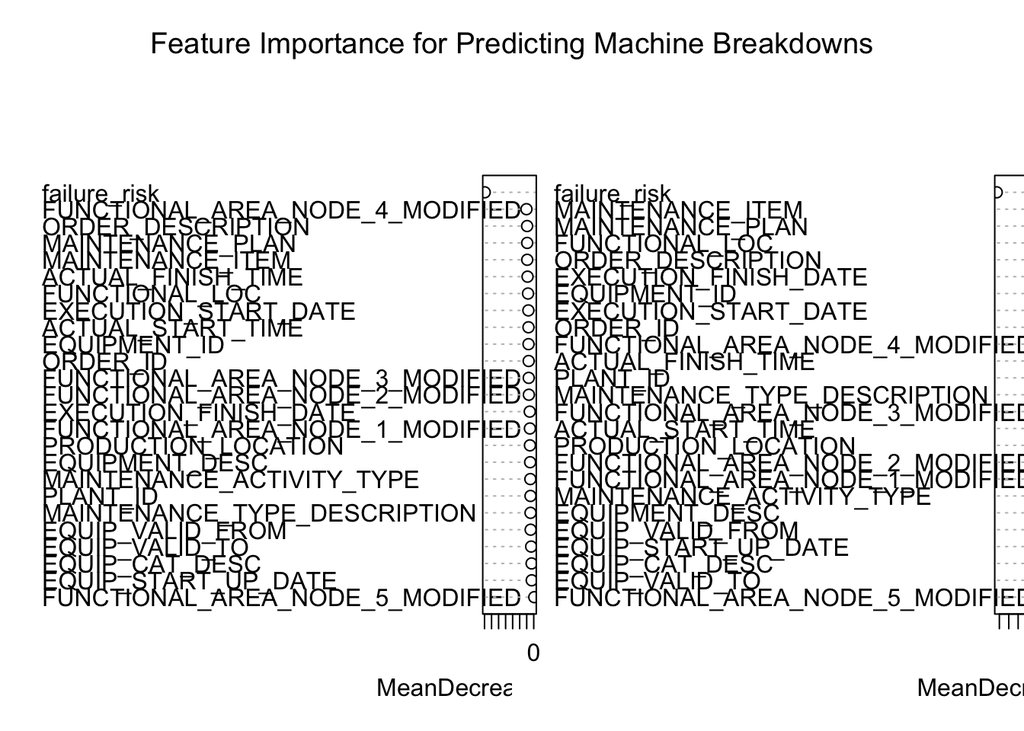

```r
# Plot feature importance
varImpPlot(rf_model, main = "Feature Importance for Predicting Machine Breakdowns")
```

Interpretation by Variable

Other variables such as MAINTENANCE_ITEM and MAINTENANCE_PLAN also play a considerable role, showing high MeanDecreaseGini values (799.15 and 721.23, respectively). This highlights the importance of maintenance details in predicting breakdowns, suggesting that specific maintenance items and plans contribute valuable insight into machine performance. Additionally, EXECUTION_START_DATE and EXECUTION_FINISH_DATE provide moderate predictive value, potentially capturing seasonal or time-based patterns that influence breakdowns. Moderate predictors like ORDER_DESCRIPTION, FUNCTIONAL_LOC, and EQUIPMENT_ID further emphasize the role of equipment-specific characteristics in failure risk. Conversely, low-importance variables such as FUNCTIONAL_AREA_NODE_5_MODIFIED and EQUIP_CAT_DESC exhibit low or negative MeanDecreaseAccuracy scores, indicating limited predictive value and suggesting they may be streamlined out of the model to improve efficiency.

## Binning Failure Risk

```r
# Check the distribution of `failure_risk` to decide on the quantiles
summary(train_data$failure_risk)
```

```
##    Min. 1st Qu.  Median    Mean 3rd Qu.    Max.
##  0.0000  0.0000  0.0000  0.1802  0.0000  1.0000
```

```r
# Replace NA in numeric columns with the median
numeric_cols <- sapply(train_data, is.numeric)
train_data[numeric_cols] <- lapply(train_data[numeric_cols], function(x) ifelse(is.na(x), median(x, na.rm = TRUE), x))
test_data[numeric_cols] <- lapply(test_data[numeric_cols], function(x) ifelse(is.na(x), median(x, na.rm = TRUE), x))

# Replace NA in categorical columns with "Unknown"
categorical_cols <- sapply(train_data, is.factor)
train_data[categorical_cols] <- lapply(train_data[categorical_cols], function(x) ifelse(is.na(x), "Unknown", x))
test_data[categorical_cols] <- lapply(test_data[categorical_cols], function(x) ifelse(is.na(x), "Unknown", x))

# Define quantile-based cutoffs for high, medium, and low risk
quantiles <- quantile(train_data$failure_risk, probs = c(0.33, 0.67), na.rm = TRUE)

# Create a new categorical variable based on these quantiles
train_data <- train_data %>%
  mutate(failure_risk_category = case_when(
    failure_risk <= quantiles[1] ~ "Low",
    failure_risk > quantiles[1] & failure_risk <= quantiles[2] ~ "Medium",
    failure_risk > quantiles[2] ~ "High"
  ))

# Convert the new feature to a factor
train_data$failure_risk_category <- as.factor(train_data$failure_risk_category)

# Repeat for test data, using the same quantiles to ensure consistency
test_data <- test_data %>%
  mutate(failure_risk_category = case_when(
    failure_risk <= quantiles[1] ~ "Low",
    failure_risk > quantiles[1] & failure_risk <= quantiles[2] ~ "Medium",
    failure_risk > quantiles[2] ~ "High"
  ))
test_data$failure_risk_category <- as.factor(test_data$failure_risk_category)

# Confirm the new categorical distribution
table(train_data$failure_risk_category)
```

```
##
##   High    Low
##  21995 100080
```

```r
# Define breakdown variable based on downtime threshold
threshold <- 60  # Example threshold for a breakdown
train_data$breakdown <- ifelse(train_data$ACTUAL_WORK_IN_MINUTES > threshold, 1, 0)
test_data$breakdown <- ifelse(test_data$ACTUAL_WORK_IN_MINUTES > threshold, 1, 0)

# Convert to factor for classification
train_data$breakdown <- as.factor(train_data$breakdown)
test_data$breakdown <- as.factor(test_data$breakdown)

# Confirm the breakdown distribution
table(train_data$breakdown)
```

```
##
##      0      1
## 100080  21995
```

```r
table(test_data$breakdown)
```

```
##
##     0     1
## 25095  5424
```

```r
# Load necessary library for rolling calculations


# Define the number of recent failures to consider
n <- 3

# Calculate the average downtime over the last `n` failures for each machine
train_data <- train_data %>%
  arrange(EQUIPMENT_ID, EXECUTION_START_DATE) %>%
  group_by(EQUIPMENT_ID) %>%
  mutate(avg_downtime_last_n = rollapply(ACTUAL_WORK_IN_MINUTES, width = n, FUN = mean, align = "right", fill = NA))

# Repeat for test data
test_data <- test_data %>%
  arrange(EQUIPMENT_ID, EXECUTION_START_DATE) %>%
  group_by(EQUIPMENT_ID) %>%
  mutate(avg_downtime_last_n = rollapply(ACTUAL_WORK_IN_MINUTES, width = n, FUN = mean, align = "right", fill = NA))

# Check the new feature
summary(train_data$avg_downtime_last_n)
```

```
##    Min. 1st Qu.  Median    Mean 3rd Qu.    Max.    NA's
##    0.00   20.00   34.60   50.85   60.00 4884.00    2817
```

```r
# Final step: remove any rows with remaining NA values in train and test sets
train_data <- train_data[complete.cases(train_data), ]
test_data <- test_data[complete.cases(test_data), ]

# Train the Random Forest model with new features
rf_model <- randomForest(
  breakdown ~ . - ACTUAL_WORK_IN_MINUTES - failure_risk,  # Exclude original downtime variable
  data = train_data,
  ntree = 100,
  mtry = 3,
  importance = TRUE
)

# View and plot feature importance
importance <- importance(rf_model)
print(importance)
```

```
##                                          0         1 MeanDecreaseAccuracy
## ORDER_ID                         5.5688300  6.665602            6.3519238
## PLANT_ID                         2.7633735  3.169301            3.2386711
## PRODUCTION_LOCATION              4.2546206  4.787050            5.1029629
## EXECUTION_START_DATE             4.2627039  5.978812            4.9848122
## EXECUTION_FINISH_DATE            6.0934848  6.402884            6.9775371
## ACTUAL_START_TIME                6.6971645  5.637406            8.2028810
## ACTUAL_FINISH_TIME               5.0184477  6.974308            6.3327778
## MAINTENANCE_PLAN                 5.5741786  6.763725            8.0347319
## MAINTENANCE_ITEM                 6.7142085  7.761620            8.4288607
## MAINTENANCE_ACTIVITY_TYPE        3.3524472  3.854751            4.5014195
## ORDER_DESCRIPTION               10.9857353  8.402810           11.3786233
## MAINTENANCE_TYPE_DESCRIPTION     3.6809255  4.404174            4.8877865
## FUNCTIONAL_LOC                   4.3403368  7.006342            6.0904906
## FUNCTIONAL_AREA_NODE_1_MODIFIED  3.4181623  3.686607            4.1832117
## FUNCTIONAL_AREA_NODE_2_MODIFIED  4.6315878  4.840960            5.9504906
## FUNCTIONAL_AREA_NODE_3_MODIFIED  6.3651045  5.612003            6.9418977
## FUNCTIONAL_AREA_NODE_4_MODIFIED  7.9748376  8.777725            9.8669459
## FUNCTIONAL_AREA_NODE_5_MODIFIED -0.1576046 -1.065530           -0.9084121
## EQUIPMENT_ID                     6.8559222  6.112313            7.9646960
## EQUIPMENT_DESC                   4.3711935  4.446928            5.5216833
## EQUIP_CAT_DESC                   2.7848752  2.991870            3.3061839
## EQUIP_START_UP_DATE              2.3182906  2.131112            2.4219433
## EQUIP_VALID_FROM                 4.5874200  3.551811            5.6446219
## EQUIP_VALID_TO                   3.1914113  1.963576            2.9835211
## failure_risk_category           68.3734300 77.554546           79.5476172
## avg_downtime_last_n              8.7370371  9.997439           12.0542688
##                                 MeanDecreaseGini
## ORDER_ID                              289.961504
## PLANT_ID                              109.548918
## PRODUCTION_LOCATION                   261.939709
## EXECUTION_START_DATE                  303.380492
## EXECUTION_FINISH_DATE                 315.097719
## ACTUAL_START_TIME                     210.297475
## ACTUAL_FINISH_TIME                    189.726483
## MAINTENANCE_PLAN                      588.680302
## MAINTENANCE_ITEM                      566.517933
## MAINTENANCE_ACTIVITY_TYPE             149.862950
## ORDER_DESCRIPTION                     352.950715
## MAINTENANCE_TYPE_DESCRIPTION          337.201711
## FUNCTIONAL_LOC                        572.719060
## FUNCTIONAL_AREA_NODE_1_MODIFIED       126.010316
## FUNCTIONAL_AREA_NODE_2_MODIFIED       204.267175
## FUNCTIONAL_AREA_NODE_3_MODIFIED       230.838409
## FUNCTIONAL_AREA_NODE_4_MODIFIED       237.172746
## FUNCTIONAL_AREA_NODE_5_MODIFIED         2.110530
## EQUIPMENT_ID                          304.852107
## EQUIPMENT_DESC                         77.401990
## EQUIP_CAT_DESC                         16.533998
## EQUIP_START_UP_DATE                    25.373302
## EQUIP_VALID_FROM                       39.620321
## EQUIP_VALID_TO                          9.688754
## failure_risk_category               22347.891989
## avg_downtime_last_n                  5534.977434
```

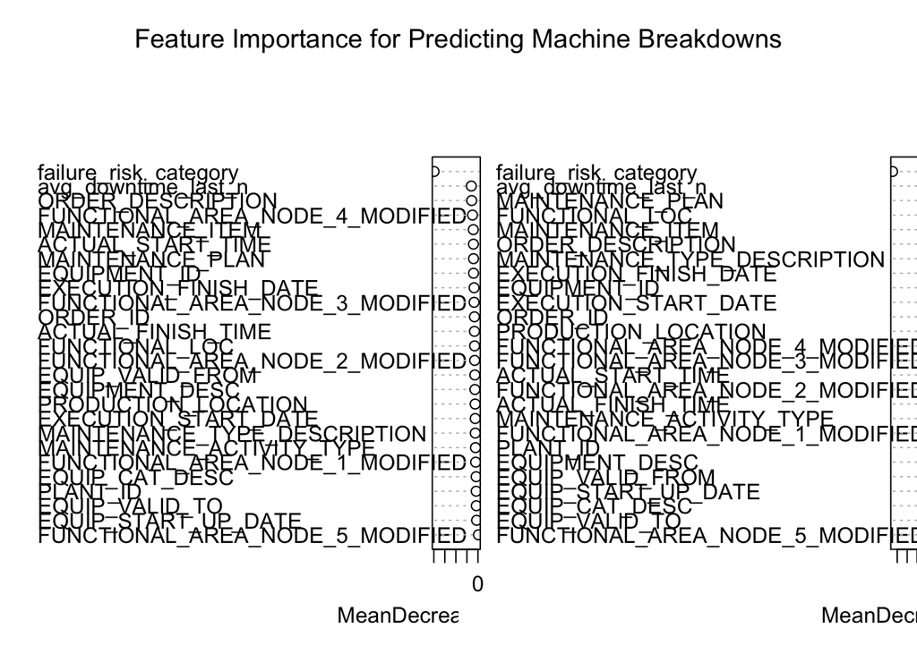

```r
# Plot feature importance
varImpPlot(rf_model, main = "Feature Importance for Predicting Machine Breakdowns")
```

# Logistic Regression Model

## Step 1: Data Cleaning and Preparation

```r
# Create data for Logistic Regression
logistic_data <- data

# Remove rows with missing `EQUIPMENT_ID`
logistic_data <- logistic_data %>% filter(!is.na(EQUIPMENT_ID))

# Filter the dataset to retain relevant columns only
logistic_data <- logistic_data %>%
  select(EQUIPMENT_ID, PLANT_ID, PRODUCTION_LOCATION,
         MAINTENANCE_ACTIVITY_TYPE, MAINTENANCE_TYPE_DESCRIPTION,
         ACTUAL_WORK_IN_MINUTES, EXECUTION_START_DATE, EQUIP_START_UP_DATE)

# Ensure date columns are in Date format
logistic_data <- logistic_data %>%
  mutate(
    EXECUTION_START_DATE = as.Date(EXECUTION_START_DATE, format = "%Y-%m-%d"),
    EQUIP_START_UP_DATE = as.Date(EQUIP_START_UP_DATE, format = "%Y-%m-%d")
  )

# Calculate machine age if it's a useful feature for maintenance prediction
logistic_data <- logistic_data %>%
  mutate(machine_age = as.numeric(difftime(EXECUTION_START_DATE, EQUIP_START_UP_DATE, units = "days")) / 365)
```

## Step 2: Define the Target Variable

```r
# Define a threshold (e.g., 60 minutes) for classifying a maintenance event as "high risk"
threshold <- 60
logistic_data <- logistic_data %>%
  mutate(high_risk = ifelse(ACTUAL_WORK_IN_MINUTES > threshold, 1, 0))

# Convert `high_risk` and other categorical variables to factors
logistic_data <- logistic_data %>%
  mutate(
    high_risk = as.factor(high_risk),
    PLANT_ID = as.factor(PLANT_ID),
    PRODUCTION_LOCATION = as.factor(PRODUCTION_LOCATION),
    MAINTENANCE_ACTIVITY_TYPE = as.factor(MAINTENANCE_ACTIVITY_TYPE),
    MAINTENANCE_TYPE_DESCRIPTION = as.factor(MAINTENANCE_TYPE_DESCRIPTION)
  )
```

## Step 3: Sample a subset of the data

```r
# Subset of 10,000 rows
set.seed(123)  # For reproducibility
logistic_data <- logistic_data[sample(nrow(logistic_data), 10000), ]
```

## Step 4: Split the Data into Training and Test Sets

```r
logistic_train_index <- createDataPartition(logistic_data$high_risk, p = 0.8, list = FALSE)
logistic_train_data <- logistic_data[logistic_train_index, ]
logistic_test_data <- logistic_data[-logistic_train_index, ]

# Align factor levels between train and test sets for categorical variables
for (col in c("PLANT_ID", "PRODUCTION_LOCATION", "MAINTENANCE_ACTIVITY_TYPE", "MAINTENANCE_TYPE_DESCRIPTION")) {
  logistic_test_data[[col]] <- factor(logistic_test_data[[col]], levels = levels(logistic_train_data[[col]]))
}
```

## Step 5: Fit the Baseline Logistic Regression Model

```r
logit_model <- glm(
  high_risk ~ . - EQUIPMENT_ID - ACTUAL_WORK_IN_MINUTES - EQUIP_START_UP_DATE - EXECUTION_START_DATE,  # Exclude unneeded columns
  data = logistic_train_data,
  family = binomial(link = "logit")
)

# Summary of the logistic regression model to check coefficients
summary(logit_model)
```

```
##
## Call:
## glm(formula = high_risk ~ . - EQUIPMENT_ID - ACTUAL_WORK_IN_MINUTES -
##     EQUIP_START_UP_DATE - EXECUTION_START_DATE, family = binomial(link = "logit"),
##     data = logistic_train_data)
##
## Coefficients: (5 not defined because of singularities)
##                                                          Estimate Std. Error
## (Intercept)                                              -0.91984    0.80662
## PLANT_IDG261                                             -0.06330    0.63092
## PLANT_IDG291                                             -0.50089    0.56355
## PLANT_IDG811                                             -0.86596    0.60992
## PLANT_IDG812                                             -0.31477    0.59227
## PLANT_IDG816                                             -0.57275    0.56857
## PRODUCTION_LOCATIONMONACO                                      NA         NA
## PRODUCTION_LOCATIONMONZA                                       NA         NA
## PRODUCTION_LOCATIONROMA                                        NA         NA
## PRODUCTION_LOCATIONSILVERSTONE                                 NA         NA
## PRODUCTION_LOCATIONSUZUKA                                      NA         NA
## MAINTENANCE_ACTIVITY_TYPEUnplanned                        0.52410    0.51044
## MAINTENANCE_TYPE_DESCRIPTIONCorrective Maintenance Order  0.50717    0.27520
## MAINTENANCE_TYPE_DESCRIPTIONPreventive Maintenance Order -0.91607    0.57559
## machine_age                                               0.09603    0.01748
##                                                          z value Pr(>|z|)
## (Intercept)                                               -1.140   0.2541
## PLANT_IDG261                                              -0.100   0.9201
## PLANT_IDG291                                              -0.889   0.3741
## PLANT_IDG811                                              -1.420   0.1557
## PLANT_IDG812                                              -0.531   0.5951
## PLANT_IDG816                                              -1.007   0.3138
## PRODUCTION_LOCATIONMONACO                                     NA       NA
## PRODUCTION_LOCATIONMONZA                                      NA       NA
## PRODUCTION_LOCATIONROMA                                       NA       NA
## PRODUCTION_LOCATIONSILVERSTONE                                NA       NA
## PRODUCTION_LOCATIONSUZUKA                                     NA       NA
## MAINTENANCE_ACTIVITY_TYPEUnplanned                         1.027   0.3045
## MAINTENANCE_TYPE_DESCRIPTIONCorrective Maintenance Order   1.843   0.0653 .
## MAINTENANCE_TYPE_DESCRIPTIONPreventive Maintenance Order  -1.592   0.1115
## machine_age                                                5.492 3.97e-08 ***
## ---
## Signif. codes:  0 '***' 0.001 '**' 0.01 '*' 0.05 '.' 0.1 ' ' 1
##
## (Dispersion parameter for binomial family taken to be 1)
##
##     Null deviance: 2367.4  on 2145  degrees of freedom
## Residual deviance: 1987.0  on 2136  degrees of freedom
##   (5855 observations deleted due to missingness)
## AIC: 2007
##
## Number of Fisher Scoring iterations: 4
```

The model indicates that machine age is one of the most significant predictor of high-risk machine breakdowns, with a highly significant positive association. This suggests that as machines age, the likelihood of a breakdown increases. However, in this dataset, machine age could only be accurately recorded for planned maintenance activities, limiting its applicability across all machine events. This means that we may not fully capture the impact of machine age on breakdown risk for machines undergoing unplanned maintenance, where age-related degradation is also likely a critical factor.

To enhance the predictive power and reliability of breakdown risk assessments, it would be beneficial to implement more comprehensive methods for tracking machine age across all maintenance activities. This could involve logging machine usage time or operational cycles more consistently, regardless of whether the maintenance is planned or unplanned. By expanding the data on machine age, the model could better identify at-risk machines and support more proactive maintenance scheduling, potentially reducing unexpected downtime and maintenance costs.

## Step 6: Predict and Evaluate the Model

```r
# Predict probabilities on the test data
logistic_test_data$predicted_prob <- predict(logit_model, newdata = logistic_test_data, type = "response")

# Convert probabilities to binary predictions based on a threshold (e.g., 0.5)
logistic_test_data$predicted_class <- ifelse(logistic_test_data$predicted_prob > 0.5, 1, 0)

# Confusion matrix to evaluate performance
confusionMatrix(as.factor(logistic_test_data$predicted_class), logistic_test_data$high_risk)
```

```
## Confusion Matrix and Statistics
##
##           Reference
## Prediction   0   1
##          0 368  98
##          1  35  51
##
##                Accuracy : 0.7591
##                  95% CI : (0.7211, 0.7942)
##     No Information Rate : 0.7301
##     P-Value [Acc > NIR] : 0.06737
##
##                   Kappa : 0.2947
##
##  Mcnemar's Test P-Value : 7.612e-08
##
##             Sensitivity : 0.9132
##             Specificity : 0.3423
##          Pos Pred Value : 0.7897
##          Neg Pred Value : 0.5930
##              Prevalence : 0.7301
##          Detection Rate : 0.6667
##    Detection Prevalence : 0.8442
##       Balanced Accuracy : 0.6277
##
##        'Positive' Class : 0
##
```

## Next Steps

### 1. Predicting Likelihood of Unplanned Maintenance

A predictive model for estimating the likelihood of unplanned maintenance would provide significant value by helping Swire Coca-Cola reduce unexpected downtime and its associated costs. By identifying equipment with a high probability of unplanned maintenance, the maintenance team can proactively intervene with preventive measures, which minimizes the risk of sudden failures. This approach supports smoother production operations and more predictable workflows, directly addressing the business need to maintain high operational efficiency and reduce costly disruptions in production.

#### Approach

To build this predictive model, we can use classification techniques such as logistic regression, random forests, or XGBoost. Key features for this model might include: - **Machine age**: Age of the equipment at the time of maintenance. - **Maintenance frequency**: Number of maintenance events over a specified period. - **Historical downtime durations**: The duration of previous downtimes for each piece of equipment.

#### Expected Business Impact

By predicting the likelihood of unplanned maintenance, the maintenance team can focus preventive efforts on high-risk equipment, thus reducing unexpected downtimes. This would lead to improved production continuity, more predictable maintenance schedules, and a reduction in reactive maintenance costs.

### 2. Clustering Analysis for Maintenance Profiles

Performing a clustering analysis on the maintenance data would enable Swire Coca-Cola to segment equipment based on shared maintenance characteristics, such as downtime duration, maintenance type, and equipment age. This analysis would reveal distinct maintenance profiles, allowing the company to tailor its maintenance strategy for each group. High-risk clusters could be targeted for more frequent preventive maintenance, while low-risk groups could be maintained less often.

#### Approach

To identify distinct maintenance profiles, clustering techniques such as K-means or hierarchical clustering could be applied. Key variables for clustering might include: - **Downtime duration**: Average or total downtime for each equipment. - **Maintenance type**: Types of maintenance actions frequently associated with specific clusters. - **Equipment age**: The age or lifecycle stage of the equipment.

#### Expected Business Impact

This tailored maintenance approach helps optimize resource allocation, reduce unnecessary maintenance costs, and ensure critical assets receive the attention they need. By aligning maintenance frequency with actual risk profiles, this approach addresses the business goal of maximizing operational efficiency and cost-effectiveness in the maintenance process.